# Lecture 10: Notebooks and Tidy Tuesday

Nick Huntington-Klein

29 April, 2020

## Notebooks

- One of the reasons Excel gets a (deserved) bad rep is because there’s *no paper trail*
- We want the source of our analysis and the way we did it to be clear
- We want work to be *reproducible*
- One great development recently has been increasing use of *notebooks*

## Notebooks

- Notebooks are files (HTML, Word, whatever) that contain both the code you use AND the output
- In many places (R, Python, many more) this can be automated - you put your code in the notebook source, and it includes the output in the same place.
- Makes it very easy to share your output!

## Notebooks

- In a business context, you might not need to share your code with the higher-ups, but the other people working with you would like to see it very much!
- RMarkdown (R) and Jupyter (Python) are very common internally in many places
- Plus, the underlying code that makes the doc is all text, making it easy to do version control and share things on GitHub

## GitHub

- Git is a process for version control
- There’s a central repository that you can branch off from, make changes, then “commit” those changes to the branch, and “push” them back to the central branch
- Most software development works this way, much of it through GitHub
- We won’t be going over it too much but it’s worth looking into. See [these slides](https://raw.githack.com/uo-ec607/lectures/master/02-git/02-Git.html#1) by Grant McDermott

## Notebooks

- Back to notebooks!
- Let’s go over the basics of setting up an RMarkdown notebook
- These can be set up in one click in RStudio
- And editing proceeds using the simple RMarkdown language
- Output can be broad - PDFs, Word, slides (these slides are all RMarkdown). We’ll focus on straightforward webpage output

## Notebooks

- In RStudio, start a new notebook with File $\rightarrow$ New File $\rightarrow$ RMarkdown
- Title it and select HTML output. Notice the file that it opens up for you gives a nice template.

## RMarkdown

- Up at the top we have the “YAML” document info

```
---
title: "Untitled"
author: "Nick Huntington-Klein"
date: "4/29/2020"
output: html_document
---
```

- This lets us set the title and author of the document. If we want the date to just be “The date we compiled the doc”, set date to `r format(Sys.time(), '%d %B, %Y')`
- Output can be changed to make PDFs, slides, etc.

## Rmarkdown

- Next we have our first *code chunk*
- Code chunks start with three backticks - ` (usually on the same key as ~) and the name of the language, with a name and options following it
- `r setup, include=FALSE` shows that this is a chunk of R code to be run. The chunk is called “setup” (name optional).
- “include = FALSE” means to not include the output in the actual document, just for R internally.

## Rmarkdown options

- Other important options for chunks: “echo = TRUE” (show code or FALSE for don’t), “eval = TRUE” (run code and show output, or don’t), and “fig.width”, “fig.height” etc. for when your output includes an image
- The `knitr::opts_chunk$set(echo = TRUE)` is option-setting code for the document. Other options include “warnings = FALSE”, “messages = FALSE” and others.
- These are minor but mostly I just want to introduce you to the idea of code being in these chunks
- You can also include code in-line with single backticks

## Code chunks

- Further down we can see how you can run code in chunks and see the output in the document
- What do we see in the doc from that `summary(cars)` if we set “echo=TRUE”?

```r
summary(cars)
```

```
##      speed           dist
##  Min.   : 4.0   Min.   :  2.00
##  1st Qu.:12.0   1st Qu.: 26.00
##  Median :15.0   Median : 36.00
##  Mean   :15.4   Mean   : 42.98
##  3rd Qu.:19.0   3rd Qu.: 56.00
##  Max.   :25.0   Max.   :120.00
```

## Code chunks

- How about with that plot with `echo=FALSE`?

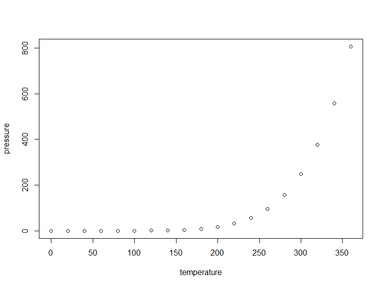

## RMarkdown

- Include all your code in there, top to bottom, as you normally would
- Make sure *all* the code is in there. Any `library()` or data read-in has to be included. It must run on a freshly-opened R session

## Markdown

- Writing in markdown! Markdown is a standard basic markup language, RMarkdown is one implementation. See [this guide too](https://rmarkdown.rstudio.com/authoring_basics.html)
- Sections start with # and ##
- Italicize with *, bold with **
- Lists with - or * or 1. 2. 3.
- Links with `[linkname](URL)` and images with `![caption](filepath)` or, better, `knitr::include_graphics()`
- Also just toss in HTML for anything that’s not standard

## Knitting

- As you go, you can hit the green arrow to run a code chunk to see its output
- Once you’re done, hit the “Knit” button to build the document
- Fix any errors and do it again until it builds
- It will pop up the result
- You can publish it to the internet with one click with the “Publish to RPubs” button

## Practice

- Make an RMarkdown document
- Add a **ggplot2** graph of anything - maybe a point graph of `mtcars` of `mpg` against `hp`?
- Make sure the code and image are both visible
- Add some text above your code explaining what your graph is.
- Add the sentence in a separate section:

This document has **a graph** in it. MPG on the graph has a mean of 20.090625. Think you can find a better graph? Try on Google Images.

## More ggplot!

- Let’s flex our RMarkdown and **ggplot** muscles
- We’ll each be doing a Tidy Tuesday in RMarkdown
- We’ll share as we work and iterate on our designs together

## Tidy Tuesday

- Head to the Tidy Tuesday GitHub repo https://github.com/rfordatascience/tidytuesday
- Let’s go to the most recent one and see if that works (whatever it is now)
- I’ll show you how to use `read_csv` to get the data into R

## Tidy Tuesday

- Make a graph in an RMarkdown document and publish on RPubs, then post your link
- We’ll look at them, see what ideas are coming up, and do revisions
- Ideally we can do a few rounds